# Taller 9

Métodos Computacionales para Políticas Públicas - URosario

**Entrega: viernes 24-abr-2020 11:59 PM**

**[Mónica Alejandra Robayo González]**  
[monica.robayo@urosario.edu.co]

## Instrucciones:

- Guarde una copia de este *Jupyter Notebook* en su computador, idealmente en una carpeta destinada al material del curso.
- Modifique el nombre del archivo del *notebook*, agregando al final un guión inferior y su nombre y apellido, separados estos últimos por otro guión inferior. Por ejemplo, mi *notebook* se llamaría: mcpp_taller9_santiago_matallana
- Marque el *notebook* con su nombre y e-mail en el bloque verde arriba. Reemplace el texto "[Su nombre acá]" con su nombre y apellido. Similar para su e-mail.
- Desarrolle la totalidad del taller sobre este *notebook*, insertando las celdas que sea necesario debajo de cada pregunta. Haga buen uso de las celdas para código y de las celdas tipo *markdown* según el caso.
- Recuerde salvar periódicamente sus avances.
- Cuando termine el taller:
  1. Descárguelo en PDF. Si tiene algún problema con la conversión, descárguelo en HTML.
  2. Suba todos los archivos a su repositorio en GitHub, en una carpeta destinada exclusivamente para este taller, antes de la fecha y hora límites.

NLTK Book (http://www.nltk.org/book/), ejercicios:

- Capítulo 1: 22, 26, 28
- Capítulo 2: 2, 4, 11

# Capitulo 1

```python
import matplotlib.pyplot as plt
plt.rcParams["figure.figsize"] = [18.0, 8.0]
```

```python
import nltk
```

```python
nltk.download()
```

```
showing info https://raw.githubusercontent.com/nltk/nltk_data/gh-pages/index.xml
```

```
True
```

```python
from nltk.book import *
```

```
*** Introductory Examples for the NLTK Book ***
Loading text1, ..., text9 and sent1, ..., sent9
Type the name of the text or sentence to view it.
Type: 'texts()' or 'sents()' to list the materials.
text1: Moby Dick by Herman Melville 1851
text2: Sense and Sensibility by Jane Austen 1811
text3: The Book of Genesis
text4: Inaugural Address Corpus
text5: Chat Corpus
text6: Monty Python and the Holy Grail
text7: Wall Street Journal
text8: Personals Corpus
text9: The Man Who Was Thursday by G . K . Chesterton 1908
```

1. Find all the four-letter words in the Chat Corpus (text5). With the help of a frequency distribution (FreqDist), show these words in decreasing order of frequency.

```python
text5
```

```
<Text: Chat Corpus>
```

```python
four_letter_words = [w for w in text5 if len(w) == 4]
```

```python
four_letter_words
```

[output not shown]

[output cut: 946 more lines]

[output not shown]

```python
# como resultado da una lista con las palabras de cuatro letras dentro del texto5
```

```python
len(four_letter_words) # longitud de la lista de cuatro letras
```

```
10204
```

```python
# da un diccionario con la frecuencia de distribución de las palabras de cuatro letras.
freqdist_tex5=FreqDist(four_letter_words)
freqdist_tex5
```

```
FreqDist({'JOIN': 1021, 'PART': 1016, 'that': 274, 'what': 183, 'here': 181, '....': 170, 'have': 164, 'like': 156, 'with': 152, 'chat': 142, ...})
```

```python
# organiza el diccionario freqdist_tex5 por su frecuencia.
import operator
sorted_x = sorted(freqdist_tex5.items(), key=operator.itemgetter(1))
```

```python
# organiza del menor al mayor
sorted_x
```

[output not shown]

[output cut: 946 more lines]

[output not shown]

```python
# se organizan de mayor a menor
sorted_x.reverse()
```

```python
#muestra cada elemento del text5 de mayor a menor por su frecuencia
sorted_x
```

```
[('JOIN', 1021),
 ('PART', 1016),
 ('that', 274),
 ('what', 183),
 ('here', 181),
 ('....', 170),
 ('have', 164),
 ('like', 156),
 ('with', 152),
 ('chat', 142),
 ('your', 137),
 ('good', 130),
 ('just', 125),
 ('lmao', 107),
 ('know', 103),
 ('room', 98),
 ('from', 92),
 ('this', 86),
 ('well', 81),
 ('hiya', 78),
 ('back', 78),
 ('they', 77),
 ('yeah', 75),
 ('dont', 75),
 ('want', 71),
 ('love', 60),
 ('some', 58),
 ('guys', 58),
 ('been', 57),
 ('talk', 56),
 ('nice', 52),
 ('time', 50),
 ('when', 48),
 ('make', 44),
 ('haha', 44),
 ('need', 43),
 ('girl', 43),
 ('U122', 42),
 ('MODE', 41),
 ('then', 40),
```

[output cut: 946 more lines]

```
 ('1.98', 1),
 ('giva', 1),
 ('coem', 1),
 ('ebay', 1),
 ('wins', 1),
 ('orta', 1),
 ('wood', 1),
 ('mite', 1),
 ('slip', 1),
 ('lake', 1),
 ('addy', 1),
 ('nawp', 1),
 ('Mary', 1),
 ('lots', 1),
 ...]
```

1. What does the following Python code do? sum(len(w) for w in text1) Can you use it to work out the average word length of a text?

```python
text1
```

```
<Text: Moby Dick by Herman Melville 1851>
```

```python
sum(len(w) for w in text1)
```

```
999044
```

```python
t1=text1
tok=sum(len(w) for w in t1)
tok
```

```
999044
```

```python
long=len(t1)
long
```

```
260819
```

```python
#Puede usarse para calcular la longitud promedio de palabra de un texto, como la suma(longitud de cada palabra)/total de palabras,así:
tok/long
```

```
3.830411128023649
```

28.Define a function percent(word, text) that calculates how often a given word occurs in a text, and expresses the result as a percentage.

```python
def percent(word,text):
    fdist=FreqDist(text)
    w_word=fdist[word]
    total=len(text)
    percent=w_word/total
    print( str(word), "appears", str(percent) + "% in ", str(text))
```

```python
percent("JOIN",text5)
```

```
JOIN appears 0.022683848033770274% in  <Text: Chat Corpus>
```

```python
percent("lots",text5)
```

```
lots appears 2.2217285047767163e-05% in  <Text: Chat Corpus>
```

```python
percent("while",text1)
```

```
while appears 0.0008281605251151181% in  <Text: Moby Dick by Herman Melville 1851>
```

# Capitulo 2

1. Use the corpus module to explore austen-persuasion.txt. How many word tokens does this book have? How many word types?

```python
from nltk.corpus import gutenberg

austen_persuasion =gutenberg.words("austen-persuasion.txt")
```

```python
#muestra la longitud de word tokens
len(austen_persuasion)
```

```
98171
```

```python
#word types, esto es el conjunto único de palabras sin repetir
len(set((w.lower() for w in austen_persuasion if w.isalpha())))
```

```
5739
```

1. Read in the texts of the State of the Union addresses, using the state_union corpus reader. Count occurrences of men, women, and people in each document. What has happened to the usage of these words over time?

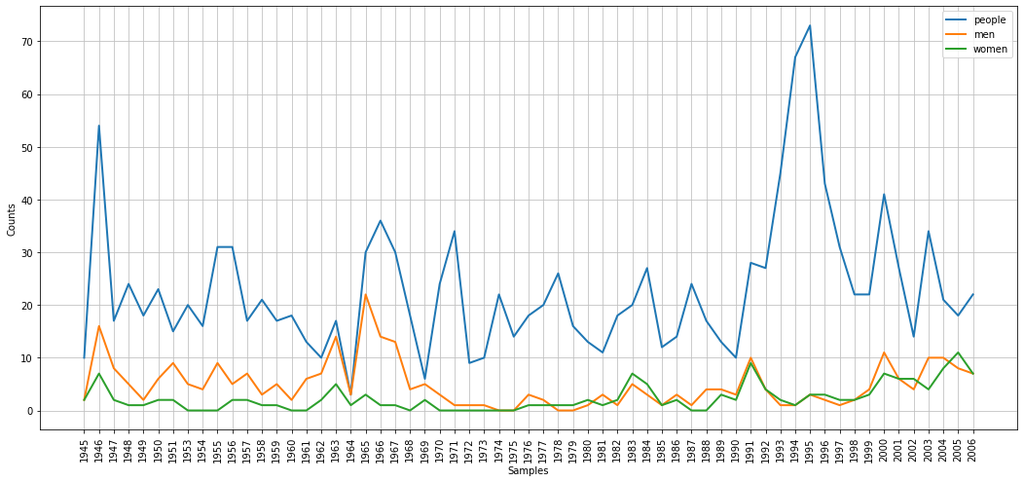

```python
# importamos libreria y se codifican loops para captar la frecuencia de los objetivos (targets)
import nltk
freq = nltk.ConditionalFreqDist((target, fileid[:4])
  for fileid in nltk.corpus.state_union.fileids()
  for v in nltk.corpus.state_union.words(fileid)

#luego se especifica que elemntos se tomarán de los discursos, esto es: (target) women, men, people
  for target in ['men', 'women', 'people']

# por ultimo se tomaca cada instancia del objeto(target) cuya forma comienza en una minúscula
  if v.lower().startswith(target))

freq.plot() ;
```

Respuesta: Se evidencia que antes de 1970 la palabra mujer casi no se usaba, pero desde dicho año se ha usado más o menos como el término hombre. El termino people ha sido más nombrado para los últimos años.

1. Investigate the table of modal distributions and look for other patterns. Try to explain them in terms of your own impressionistic understanding of the different genres. Can you find other closed classes of words that exhibit significant differences across different genres?

```python
from nltk.corpus import brown
brown.categories()
```

```
['adventure',
 'belles_lettres',
 'editorial',
 'fiction',
 'government',
 'hobbies',
 'humor',
 'learned',
 'lore',
 'mystery',
 'news',
 'religion',
 'reviews',
 'romance',
 'science_fiction']
```

```python
freq2 = nltk.ConditionalFreqDist((genre, word)

       for genre in brown.categories()
       for word in brown.words(categories=genre))

genres = ['editorial',
 'fiction',
 'government',
 'hobbies',
 'humor',
 'learned',
 'lore',
 'mystery',
 'news',
 'religion',
 'reviews',
 'romance',
 'science_fiction' ]

general_words = ['can', 'could', 'may', 'might', 'must', 'will']

freq2.tabulate(conditions=genres, samples=general_words)
```

```
                  can could   may might  must  will
      editorial   121    56    74    39    53   233
        fiction    37   166     8    44    55    52
     government   117    38   153    13   102   244
        hobbies   268    58   131    22    83   264
          humor    16    30     8     8     9    13
        learned   365   159   324   128   202   340
           lore   170   141   165    49    96   175
        mystery    42   141    13    57    30    20
           news    93    86    66    38    50   389
       religion    82    59    78    12    54    71
        reviews    45    40    45    26    19    58
        romance    74   193    11    51    45    43
science_fiction    16    49     4    12     8    16
```

```python
freq3 = nltk.ConditionalFreqDist((genre1, word)

       for genre1 in brown.categories()
       for word in brown.words(categories=genre1))

genres1 = ['editorial',
 'fiction',
 'government',
 'hobbies',
 'humor',
 'learned',
 'lore',
 'mystery',
 'news',
 'religion',
 'reviews',
 'romance',
 'science_fiction' ]

general_words1 = ['what', 'where', 'when', 'why', 'which']

freq3.tabulate(conditions=genres1, samples=general_words1)
```

```
                 what where  when   why which
      editorial    84    40   103    10   191
        fiction   128    76   133    18   123
     government    43    46    56     6   263
        hobbies    78    72   119    10   252
          humor    36    15    52     9    62
        learned   141   118   227    20   832
           lore   130    97   182    25   275
        mystery   109    59   114    25    58
           news    76    58   128     9   244
       religion    64    20    53    14   202
        reviews    44    25    54     9   123
        romance   121    54   126    34   104
science_fiction    27    10    21     4    32
```

Se evidencia que en la categoría Learned la palabra "which" es la más usada. Además la palabra que menos es usada en las categorías es Why y la más usada en which.